# Homework 6: Text Mining

Herman

### **Instructions**

You can submit your homework in one of two ways.

1. You can fill in the missing code blocks directly in this .Rmd file (be sure to change the file name)
2. You can create a new .R file and clearly label you answers.

### Packages

```r
# load the packages
library(tidyverse)
library(tidytext)
library(textdata)
library(gridExtra)
library(quanteda)
library(tm)
library(topicmodels)
library(wordcloud)
# set the working directory
setwd("~/Text-Mining")
# load the data
state_data <- read_csv("./state_of_the_union.csv")
```

### Getting started: State of the Union dataset

- We’re going to start by operating on the `state_of_the_union.csv` file. This is the dataset we used in class. It contains the State of the Union address from George Washington to Theodore Roosevelt.

### **Problem Set**

**Problem 1**: Perform sentiment analysis on each of George Washington’s State of the Union address using the AFINN and bing sentiment dictionary, use `stop_words` to remove stop words. Note that during his presidency George Washington gave eight different State of the Union addresses.

- Which speech was George Washington the most positive according to the AFINN and Bing sentiment dictionary?
- Which speech was George Washington the most negative according to the AFINN and Bing sentiment dictionary?

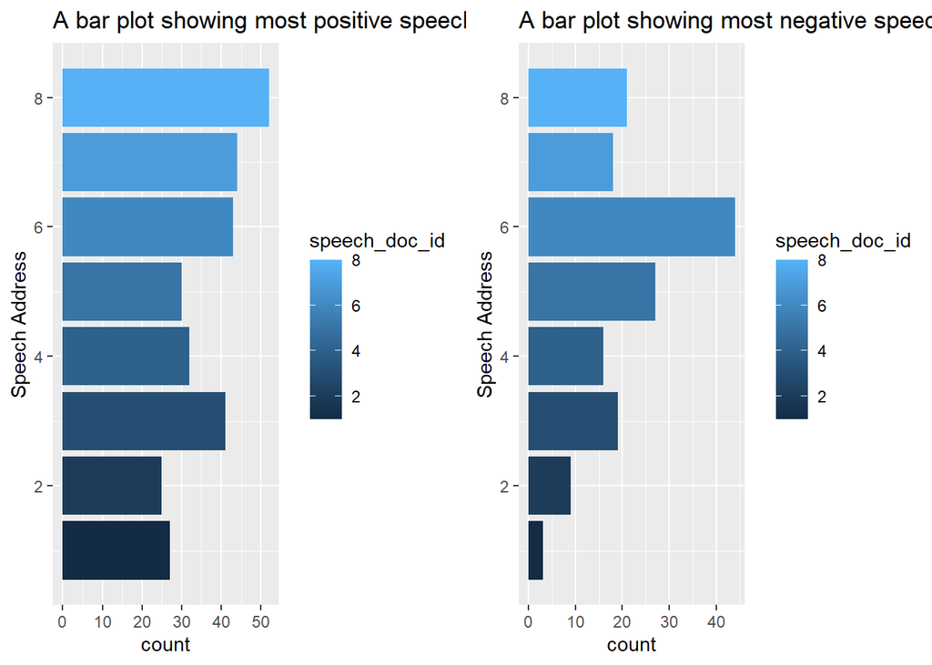

```r
# select the text
george_speech <- state_data %>%
  filter(president == 'George Washington')

text <- george_speech$text
# clean the text
# Remove newline characters and panctuation and convert to lowercases
clean_text <- tolower(gsub("[\n\r[:punct:]]", "", text))

text_df <- tibble(
  line = 1:length(text),
  text = text,
  speech_doc_id = george_speech$speech_doc_id
)
#break the text into individual tokens ie tokenisation
#use unnest_tokens() from tidytext package
tidy_text <- text_df %>%
  unnest_tokens(word, text) %>%
  filter(!grepl('[0-9]', word))

#remove the stop_words with anti_join()
data("stop_words")
tidy_text <- tidy_text %>%
  anti_join(stop_words)

# afinn and bing sentiment dictionary
afinn <- get_sentiments('afinn')
bing <- get_sentiments('bing')
# apply both to data
sentiments <- tidy_text %>%
  inner_join(afinn) %>%
  inner_join(bing) %>%
  mutate(
    sentiment = case_when(
      value > 0 & sentiment == 'positive' ~ 'positive',
      value < 0 & sentiment == 'negative' ~ 'negative',
      TRUE ~ 'neutral'
    )
  )
# positive sentiment
positive_sentiment <- sentiments %>%
  filter(sentiment == 'positive') %>%
  group_by(speech_doc_id) %>%
  summarize(count = n()) %>%
  arrange(desc(count))
# negative sentiment
negative_sentiment <- sentiments %>%
  filter(sentiment == 'negative') %>%
  group_by(speech_doc_id) %>%
  summarize(count = n()) %>%
  arrange(desc(count))
# positive sentiment barplot
pos_barplot <- positive_sentiment %>%
  ggplot(aes(x = speech_doc_id, y = count, fill = speech_doc_id)) +
  geom_bar(stat = 'identity') +
  coord_flip() +
  labs(title = "A bar plot showing most positive speech and which address it comes from",
       x = 'Speech Address', y = 'count')
# negative sentiment barplot
neg_barplot <- negative_sentiment %>%
  ggplot(aes(x = speech_doc_id, y = count, fill = speech_doc_id)) +
  geom_bar(stat = 'identity') +
  coord_flip() +
  labs(title = "A bar plot showing most negative speech and which address it comes from",
       x = 'Speech Address', y = 'count')
grid.arrange(pos_barplot, neg_barplot, ncol = 2)
```

**Problem 2.** Answer the following removing stop words using `stopwords`.

- Across the entire dataset, which president gave the single most positive address according to the ncr sentiment dictionary?
- Which president gave this address and what was the date of this address?
- Across the entire dataset, which president gave the single most negative speech according to the ncr sentiment dictionary?
- Which president gave this address and what was the date of this address?

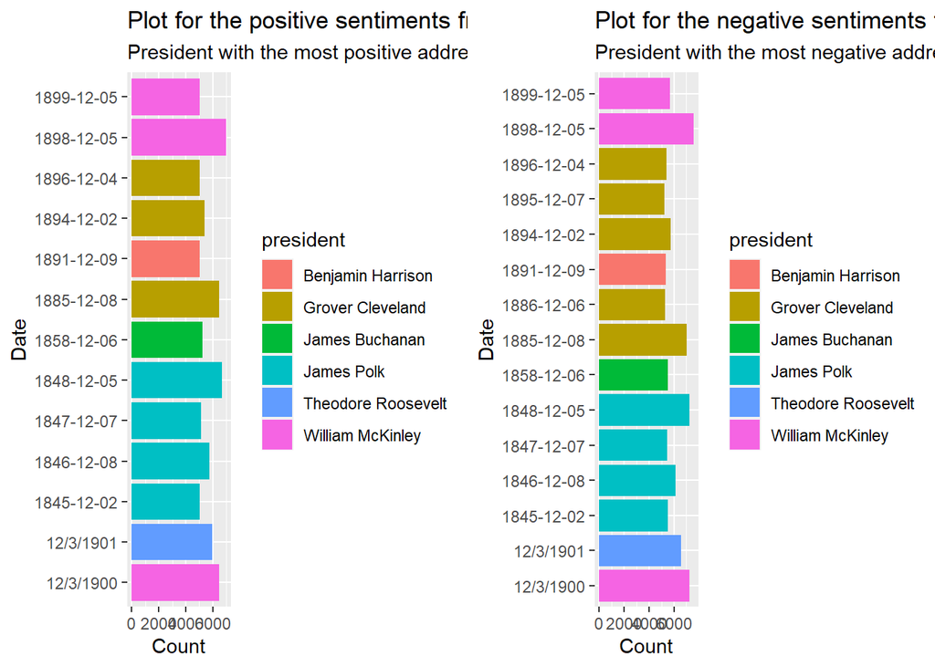

```r
# Preprocess the text
text1 <- tolower(gsub("[\n\r[:punct:]]", " ", state_data$text))
text_df1 <-
  tibble(
    line = 1:length(text1),
    text = text1,
    president = state_data$president,
    date = state_data$date
  )

# Tokenize the text
tidy_text1 <- text_df1 %>%
  unnest_tokens(word, text) %>%
  filter(!grepl('[0-9]', word))
# stop words
data("stop_words")
tidy_text1 <- tidy_text1 %>%
  anti_join(stop_words)
# nrc for positive and negative sentiment
nrc_positive <- get_sentiments('nrc') %>%
  filter(sentiment == 'positive')

nrc_negative <- get_sentiments('nrc') %>%
  filter(sentiment == 'negative')
# get the positive and negative sentiments
positive_sentiments <- tidy_text1 %>%
  anti_join(nrc_positive) %>%
  group_by(president, date) %>%
  summarize(count = n()) %>%
  arrange(desc(count))

negative_sentiments <- tidy_text1 %>%
  anti_join(nrc_negative) %>%
  group_by(president, date) %>%
  summarize(count = n()) %>%
  arrange(desc(count))
# plot for president with positive and negative sentiment
#first 10
positive_sentiment_plot <- positive_sentiments %>%
  filter(count >= 5000) %>%
  ggplot(aes(x = date, y = count, fill = president)) +
  geom_col() +
  coord_flip() +
  labs(
    title = 'Plot for the positive sentiments from different president',
    subtitle = 'President with the most positive address is William McKinley and the date is 1898-12-05 with 6986 positive words',
    x = "Date",
    y = 'Count'
  )
negative_sentiment_plot <- negative_sentiments %>%
  filter(count >= 5000) %>%
  ggplot(aes(x = date, y = count, fill = president)) +
  geom_col() +
  coord_flip() +
  labs(
    title = 'Plot for the negative sentiments from different presidents in different time period',
    subtitle = 'President with the most negative address is William Mckinley and the date is 1898-12-05 with a count of 7593 negative words',
    x = 'Date',
    y = 'Count'
  )
grid.arrange(positive_sentiment_plot, negative_sentiment_plot, ncol = 2)
```

**Problem 3.** This question involves performing LDA on the `state_of_the_union.csv` datasets to determine if there are key themes among presidential addresses. Complete the following

- Create a custom stop words dictionary by taking `stop_words` and appending `government`, `united`, `states`, `congress`, `country`, `american`, `citizens`, `public`, and `people`.
- Create your word count data frame with these custom stop words for each president’s speech.
- Create a term document matrix
- Perform LDA with an initial seed of 1337 and 5 groups
- Create a visualization of the top 10 terms in each of the 5 groups
- Based on the top 10 terms in each group, create a labeling for each group.

```r
# custom stop words
words <-
  c(
    'government',
    'united',
    'states',
    'congress',
    'country',
    'american',
    'citizens',
    'public',
    'people'
  )
custom_stop_words <- bind_rows(tibble(word = words,
                                      lexicon = c(rep(
                                        "custom", times = length(words)
                                      ))),
                               stop_words)
# word counts as per the president speech
speech <- tolower(gsub("[\n\r[:punct:]]", " ", state_data$text))
speech_df <- tibble(
  line = 1:length(speech),
  text = speech,
  president = state_data$president
)
speech_df <- speech_df %>%
  unnest_tokens(word, text) %>%
  filter(!grepl('[0-9]', word)) %>%
  anti_join(custom_stop_words, by = 'word')
# create word count data frame
word_count <- speech_df %>%
  group_by(president) %>%
  count(word, president, sort = TRUE)

# view the resulting word count data frame
word_count
```

```
## # A tibble: 87,204 × 3
## # Groups:   president [23]
##    president        word             n
##    <chr>            <chr>        <int>
##  1 James Polk       mexico         360
##  2 James Polk       war            251
##  3 Grover Cleveland service        175
##  4 James Buchanan   constitution   175
##  5 Grover Cleveland time           171
##  6 Andrew Jackson   subject        165
##  7 Grover Cleveland gold           163
##  8 Grover Cleveland law            156
##  9 James Polk       texas          148
## 10 Grover Cleveland secretary      142
## # ℹ 87,194 more rows
```

[figure not shown]

```r
# term document matrix
tidy_text_df <- tibble(line = 1:length(speech), text = speech)
tidy_text_df <- tidy_text_df %>%
  unnest_tokens(word, text) %>%
  anti_join(stop_words)
term_doc_matrix <- tidy_text_df$word %>%
  TermDocumentMatrix()

# perform lda
k <- 5
# Fit the LDA model
lda <- LDA(term_doc_matrix, k, control = list(seed = 1337))

# word-topic probabilities
lda_topics <- tidy(lda, matrix = 'beta')
lda_top_terms <- lda_topics %>%
  group_by(topic) %>%
  slice_max(beta, n = 10) %>%
  ungroup() %>%
  arrange(topic, -beta)
# visualize top 10
lda_top_terms %>%
  mutate(term = reorder_within(term, beta, topic)) %>%
  ggplot(aes(beta, term, fill = factor(topic))) +
  geom_col(show.legend = F) +
  facet_wrap( ~ topic, scale = 'free') +
  scale_y_reordered()
```

**Problem 4.** Create a single word cloud containing at most 500 wrods of all Abraham Lincoln’s speeches, with the stop words + custom stop words removed.

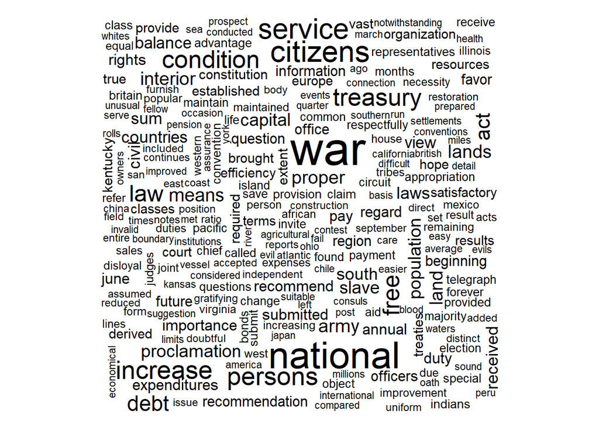

```r
## question 4
abraham_lincoln_data <- state_data %>%
  filter(president == 'Abraham Lincoln')
abraham_lincoln_speech <-
  tolower(gsub("[\n\r[:punct:]]", " ", abraham_lincoln_data$text))
abraham_lincoln_df <- tibble(line = 1:length(abraham_lincoln_speech),
                             text = abraham_lincoln_speech)
abraham_lincoln_df <- abraham_lincoln_df %>%
  unnest_tokens(word, text) %>%
  filter(!grepl('[0-9]', word)) %>%
  anti_join(stop_words)
abraham_lincoln_df %>%
  count(word, sort = TRUE) %>%
  slice_max(n, n = 500) %>%
  with(wordcloud(word, n))
```